# Clustering Lab

Adriel Kim

10/19/2021

In a separate Rmarkdown document work through a similar process with the NBA data (nba2020-21 and nba_salaries_21), merge them together.

You are a scout for the worst team in the NBA, probably the Wizards. Your general manager just heard about Data Science and thinks it can solve all the teams problems!!! She wants you to figure out a way to find players that are high performing but maybe not highly paid that you can steal to get the team to the playoffs!

Details:

- Determine a way to use clustering to estimate based on performance if players are under or over paid, generally.
- Then select three players you believe would be best for your team and explain why.
- Provide a well commented and clean (knitted) report of your findings that can be presented to your GM. Include a rationale for variable selection, details on your approach and a overview of the results with supporting visualizations.

Hints:

- Salary is the variable you are trying to understand
- You can include numerous performance variables in the clustering but when interpreting you might want to use graphs that include variables that are the most correlated with Salary
- You’ll need to standardize the variables before performing the clustering
- Be specific about why you selected the players that you did, more detail is better
- Use good coding practices, comment heavily, indent, don’t use for loops unless totally necessary and create modular sections that align with some outcome. If necessary create more than one script,list/load libraries at the top and don’t include libraries that aren’t used.

```r
# Load libraries.
#library(e1071)
library(tidyverse)
```

```r
library(plotly)
library(htmltools)
library(devtools)
library(caret)
```

### Load data and Preprocessing

Here, I merge NBA data, omit any rows with NA attributes, and rename columns.

```r
nba_salaries = read_csv("../data/nba_salaries_21.csv")
nba_stats = read_csv("../data/nba2020-21.csv")
nba_merged = merge(nba_salaries, nba_stats, by = "Player")
nba_processed = na.omit(nba_merged)#remove any rows with NA in them
names(nba_processed)[names(nba_processed) == "2020-21"] <- "Salary"
```

### Clustering variable selection

Here I select 5 different variables which I believe are highly correlated with salary and skill level. FG% is percentage of field goals, eFG% is similar with more weight toward 3-pointers, TRB is total number of rbounds, PTS is points, and BLK is number of blocks. These variables, when maximized are good indicators of a players skill level. I assume here that a player’s skill level is directly related to a player’s salary.

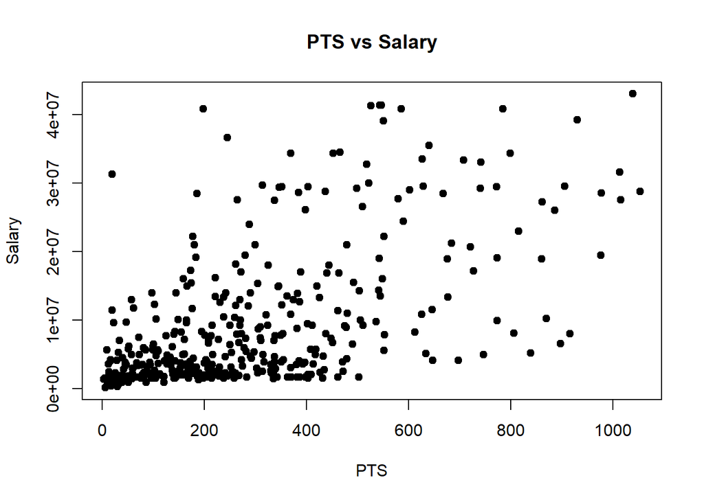

```r
plot(nba_processed$PTS, nba_processed$Salary, main="PTS vs Salary",
   xlab="PTS", ylab="Salary", pch=19)
```

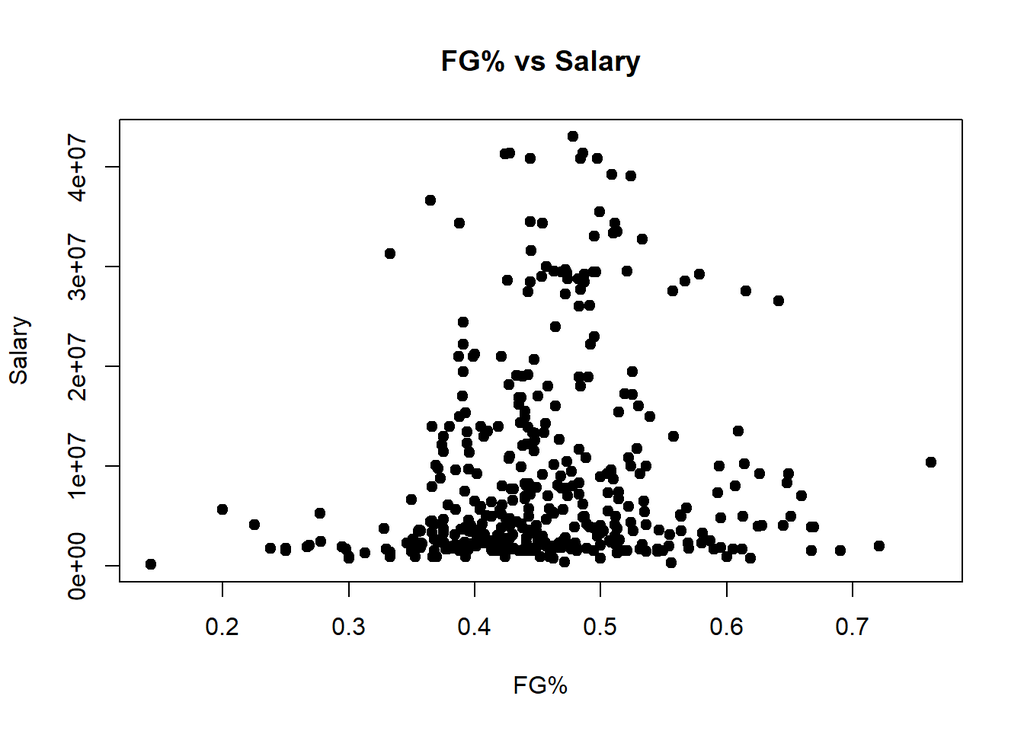

```r
plot(nba_processed$"FG%", nba_processed$Salary, main="FG% vs Salary",
   xlab="FG%", ylab="Salary", pch=19)
```

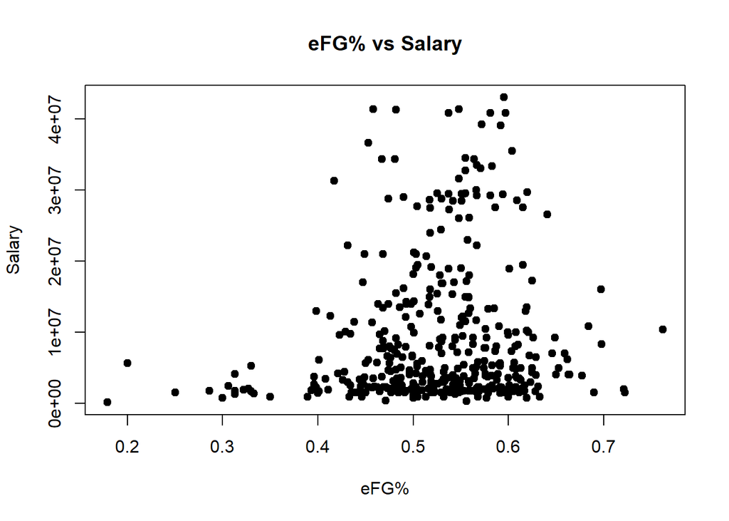

```r
plot(nba_processed$"eFG%", nba_processed$Salary, main="eFG% vs Salary",
   xlab="eFG%", ylab="Salary", pch=19)
```

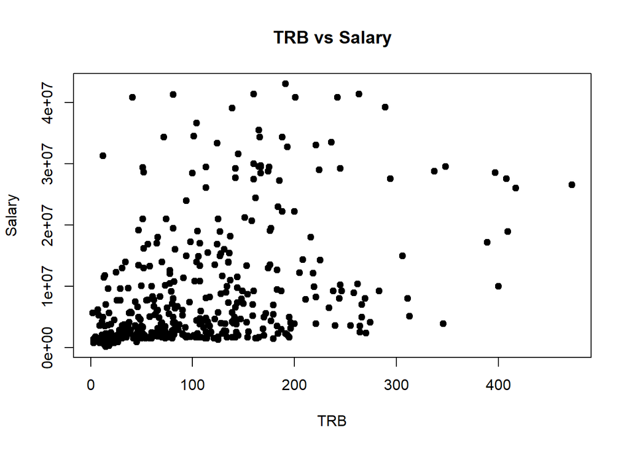

```r
plot(nba_processed$TRB, nba_processed$Salary, main="TRB vs Salary",
   xlab="TRB", ylab="Salary", pch=19)
```

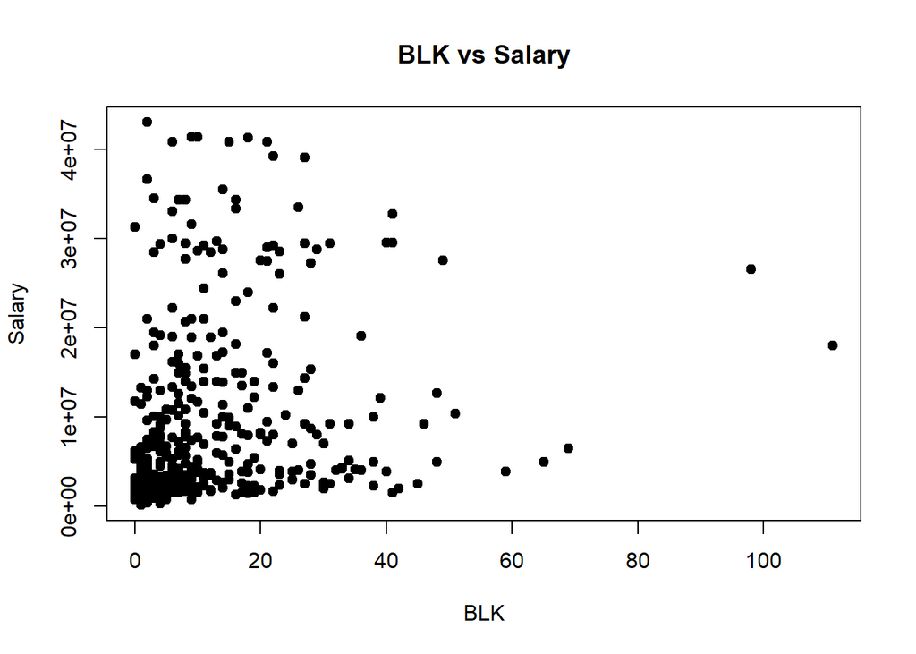

```r
plot(nba_processed$BLK, nba_processed$Salary, main="BLK vs Salary",
   xlab="BLK", ylab="Salary", pch=19)
```

```r
nba_cluster_vars = scale(nba_processed[, c("FG%", "eFG%","TRB", "PTS", "BLK")])
```

### KMeans Clustering

I create two clusters using the Lloyd clustering algorithm.

```r
set.seed(42)
#cluster based on pay?
kmeans_obj_nba = kmeans(nba_cluster_vars, centers = 2, algorithm = "Lloyd")

kmeans_obj_nba
```

```
## K-means clustering with 2 clusters of sizes 279, 139
##
## Cluster means:
##          FG%       eFG%        TRB        PTS        BLK
## 1 -0.3357106 -0.2688436 -0.5232243 -0.4600902 -0.4375085
## 2  0.6738364  0.5396213  1.0502129  0.9234903  0.8781645
##
## Clustering vector:
##   1   2   3   4   5   6   7   9  10  11  12  13  14  15  16  18  19  20  21  22
##   1   1   1   1   1   2   1   1   2   1   2   2   1   2   1   2   1   1   2   1
##  23  24  25  26  27  28  29  30  31  32  33  34  35  36  37  38  39  40  41  42
##   2   1   1   1   1   1   2   1   2   2   1   2   1   1   2   2   1   2   2   2
##  43  44  45  46  47  48  49  50  51  52  53  54  55  57  58  59  60  61  62  63
##   1   1   1   2   1   1   1   1   1   2   1   1   1   2   2   1   2   1   1   1
##  65  66  67  68  69  70  72  73  74  75  76  77  79  80  81  83  84  85  86  87
```

[output cut: 44 more lines]

```r
# View the results of each output of the kmeans function.
head(kmeans_obj_nba)
```

```
## $cluster
##   1   2   3   4   5   6   7   9  10  11  12  13  14  15  16  18  19  20  21  22
##   1   1   1   1   1   2   1   1   2   1   2   2   1   2   1   2   1   1   2   1
##  23  24  25  26  27  28  29  30  31  32  33  34  35  36  37  38  39  40  41  42
##   2   1   1   1   1   1   2   1   2   2   1   2   1   1   2   2   1   2   2   2
##  43  44  45  46  47  48  49  50  51  52  53  54  55  57  58  59  60  61  62  63
##   1   1   1   2   1   1   1   1   1   2   1   1   1   2   2   1   2   1   1   1
##  65  66  67  68  69  70  72  73  74  75  76  77  79  80  81  83  84  85  86  87
##   2   1   1   1   2   1   1   1   1   1   1   1   2   1   1   1   2   1   2   1
##  88  89  90  91  92  93  94  95  96  97  98  99 100 101 103 104 105 106 107 108
##   1   1   1   2   1   1   1   2   1   1   1   1   2   2   2   1   2   1   1   1
## 109 110 111 112 113 114 115 116 117 118 119 120 121 122 123 124 125 126 127 128
##   1   1   1   1   2   2   1   1   1   1   1   2   1   1   1   2   2   1   1   2
## 129 131 132 133 134 135 136 138 139 140 141 143 144 145 146 147 149 150 151 152
##   1   2   1   2   1   1   1   1   1   1   1   1   1   1   1   1   1   1   2   1
```

[output cut: 45 more lines]

### Visualizations

[figure not shown]

```r
#Visualize the output
clusters_nba = as.factor(kmeans_obj_nba$cluster)


ggplot(nba_processed, aes(x = TRB,
                            y = PTS,
                            shape = clusters_nba)) +
  geom_point(size = 6) +
  ggtitle("PTS vs. FG% of NBA Players in 2020-21") +
  xlab("TRB (Total Rebounds)") +
  ylab("PTS (Points)") +
  scale_shape_manual(name = "Cluster",
                     labels = c("Cluster 1", "Cluster 2"),
                     values = c("1", "2")) +
  theme_light()
```

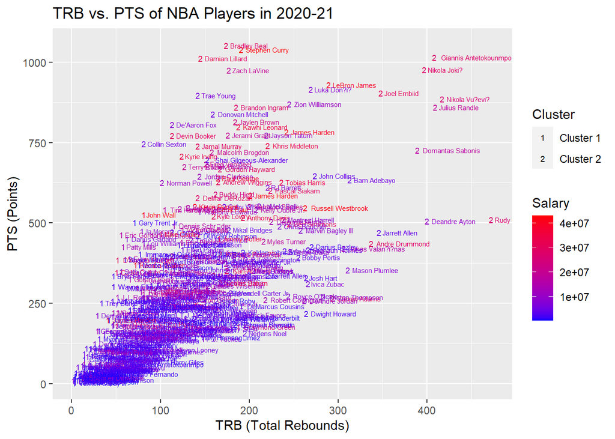

```r
player_label_usable=str_replace_all(nba_processed$Player,"[^[:graph:]]", " ")

ggplot(nba_processed, aes(  label=player_label_usable,
                            x = TRB,
                            y = PTS,
                            color = Salary,  #<- tell R how to color
                            #   the data points
                            shape = clusters_nba)) +
  geom_point(size = 2) +
  geom_text(size=2, hjust= -0.1, nudge_x=0.1)+
  ggtitle("TRB vs. PTS of NBA Players in 2020-21") +
  xlab("TRB (Total Rebounds)") +
  ylab("PTS (Points)") +
  scale_shape_manual(name = "Cluster",
                     labels = c("Cluster 1", "Cluster 2"),
                     values = c("1", "2")) +
  scale_color_gradient(low="blue", high="red")
```

```r
  theme_light()
```

[output not shown]

[output cut: 372 more lines]

[output not shown]

### Clustering Evauation

```r
#Evaluate the quality of the clustering
# Inter-cluster variance,
num_nba = kmeans_obj_nba$betweenss

# Total variance, "totss" is the sum of the distances
# between all the points in the data set.
denom_nba = kmeans_obj_nba$totss

# Variance accounted for by clusters.
(var_exp_Rep = num_nba / denom_nba)
```

```
## [1] 0.3468053
```

```r
#Use the function we created to evaluate several different number of clusters

# Run an algorithm with 3 centers.
set.seed(1)
kmeans_obj_nba3 = kmeans(nba_cluster_vars, centers = 3, algorithm = "Lloyd")
# Inter-cluster variance.
num_nba3 = kmeans_obj_nba3$betweenss

# Total variance.
denom_nba3 = kmeans_obj_nba3$totss

# Variance accounted for by clusters.
(var_exp_nba3 = num_nba3 / denom_nba3)
```

```
## [1] 0.4345576
```

```r
total.var = var(nba_cluster_vars[,c("FG%")])+var(nba_cluster_vars[,c("eFG%")])+var(nba_cluster_vars[,c("TRB")])+var(nba_cluster_vars[,c("PTS")])+var(nba_cluster_vars[,c("BLK")])

total.var.km = (kmeans_obj_nba$betweenss+kmeans_obj_nba$tot.withinss)/(nrow(nba_cluster_vars)-1)

total.var
```

```
## [1] 5
```

```r
total.var.km
```

```
## [1] 5
```

### Elbow Plot to Determine Best K

```r
# The function explained_variance wraps our code for calculating
# the variance explained by clustering.
explained_variance = function(data_in, k){

  # Running the kmeans algorithm.
  set.seed(1)
  kmeans_obj = kmeans(data_in, centers = k, algorithm = "Lloyd", iter.max = 30)

  # Variance accounted for by clusters:
  # var_exp = intercluster variance / total variance
  var_exp = kmeans_obj$betweenss / kmeans_obj$totss
  var_exp
}
```

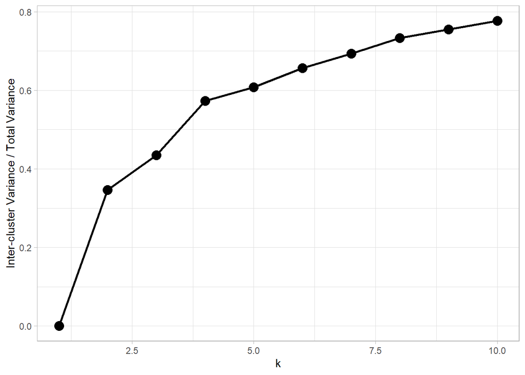

```r
#Create a elbow chart of the output
# Recall the variable we are using for the data that we're clustering.
View(nba_cluster_vars)

# The sapply() function plugs in several values into our explained_variance function.
#sapply() takes a vector, lapply() takes a dataframe
explained_var_nba = sapply(1:10, explained_variance, data_in = nba_cluster_vars)
View(explained_var_nba)


# Data for ggplot2.
elbow_data_nba = data.frame(k = 1:10, explained_var_nba)
View(elbow_data_nba)

# Plotting data.
ggplot(elbow_data_nba,
       aes(x = k,
           y = explained_var_nba)) +
  geom_point(size = 4) +           #<- sets the size of the data points
  geom_line(size = 1) +            #<- sets the thickness of the line
  xlab('k') +
  ylab('Inter-cluster Variance / Total Variance') +
  theme_light()
```

It seems here that the best K is between 2 and 5.

### Conclusion

My top three players would be Luka Doncic, Zion Williamson, and Donavan Mitchel. All three players exhibit high levels of skill in the visualization above. Both have a high number of points and total rebounds, which are strong indicators of their skill level. However, they seem underpaid compared to other players within their same cluster. Their salaries are indicated by the label color, which is closer to blue. They would be good candidates to select for our team which requires highly skilled but less expensive players.